# Secondary analysis of atac-seq data (part 2)

## Introduction

This is in addition to the `homer-analysis.Rmd` file. See that file for further context.

In addition to the inputs and outputs of `homer-analysis.Rmd`, inputs consisted of:  
* bedtools installation (https://bedtools.readthedocs.io/en/latest/content/installation.html) * hg38 denylist and chromosome size files. Run the following lines in terminal to download.

```bash
# Get denylist file
wget -L https://raw.githubusercontent.com/Boyle-Lab/Blacklist/master/lists/hg38-blacklist.v2.bed.gz && gunzip hg38-blacklist.v2.bed.gz
mv hg38-blacklist.v2.bed background-peaks/hg38-denylist.v2.bed

# Get the human chromosome size file
wget --timestamping ftp://hgdownload.cse.ucsc.edu/goldenPath/hg38/bigZips/hg38.chrom.sizes -O background-peaks/hg38.chrom.sizes
gunzip background-peaks/hg38.chrom.sizes
hg38.chrom.sizes
```

[output not shown]

## Volcano Plots of deseq results

This is a volcano plot of the deseq results prior to filtering the results to consider only those peaks with at least one of the individual peaks contributing to a given consensus peak having a -log10qval > 4.

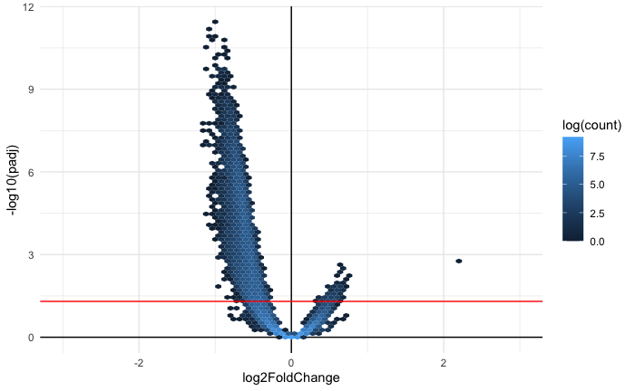

```r
res.unfiltered <- read.table("Output/differential_results_unfiltered.tsv", header = TRUE, row.names = 1, sep = "\t", stringsAsFactors = FALSE)

res.unfiltered %>%
  ggplot(aes(x = log2FoldChange, y = -log10(padj), label = rownames(as.data.frame(res.unfiltered)))) +
  geom_hline(yintercept = 0) +
  geom_vline(xintercept = 0) +
  geom_hex(bins = 75, aes(fill = stat(log(count)))) +
  theme_minimal() +
  scale_color_manual(values = c("black", "blue", "red")) +
  geom_text_repel() +
  geom_hline(yintercept = 1.301, color="red") +
  xlim(-3, 3)
```

This is a volcano plot of the deseq results after filtering the results such that the consensus peaks considered are only those with at least one of the individual peaks contributing to a given consensus peak having a -log10qval > 4.

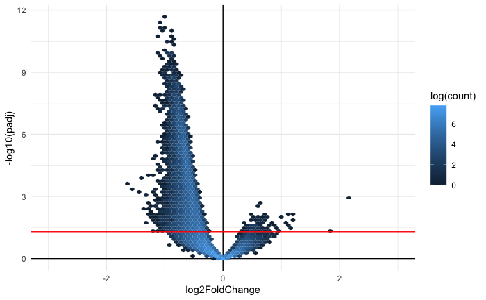

```r
res.filtered <- read.table("Output/differential_results_filtered.tsv", header = TRUE, row.names = 1, sep = "\t", stringsAsFactors = FALSE)

as.data.frame(res.filtered) %>%
  ggplot(aes(x = log2FoldChange, y = -log10(padj), label = rownames(as.data.frame(res.filtered)))) +
  geom_hline(yintercept = 0) +
  geom_vline(xintercept = 0) +
  geom_hex(bins = 75, aes(fill = stat(log(count)))) +
  theme_minimal() +
  scale_color_manual(values = c("black", "blue", "red")) +
  geom_text_repel() +
  geom_hline(yintercept = 1.301, color="red") +
  xlim(-3, 3)
```

## Differential analysis between 3MB and DMSO on background peaks

In the main homer analysis, deseq was run on the consensus peaks, comparing 3MB and DMSO cell-lines. Here, we will run deseq on a random subset of non-peaks, comparing 3MB and DMSO cell-lines. This will serve as a control. To do this, we need to create background peaks comparable to the consensus differential peaks.

First, we convert the consensus peaks into a bed file. We will also format the denylist file.

```r
peaks.consensus.boolean <- as.data.frame(read.table("Input/consensus_peaks.mRp.clN.boolean.txt", sep = "\t", header = TRUE))
write.table(peaks.consensus.boolean[, c(1, 2, 3)],
            "background-peaks/consensus_peaks.bed",
            quote = FALSE,
            row.names = FALSE,
            col.names = FALSE,
            sep = "\t")

denylist <- as.data.frame(read.table("background-peaks/hg38-denylist.v2.bed", sep = "\t", header = FALSE))
write.table(denylist[, c(1, 2, 3)],
            "background-peaks/hg38-denylist.v2.bed",
            quote = FALSE,
            row.names = FALSE,
            col.names = FALSE,
            sep = "\t")
```

Next, we need to randomly select the same number and size background peaks, excluding regions that are in consensus peaks or in our denylist file. These commands should be run from the terminal. The final command can be run multiple times with varying seeds (see `background-peaks/create-background-peaks.sh`). The seeds allow for reproducibility despite random selection.

```bash
# Create exclusion file
cat background-peaks/consensus_peaks.bed background-peaks/hg38-denylist.v2.bed > background-peaks/exclude-areas.bed
bedtools sort -i background-peaks/exclude-areas.bed > background-peaks/exclude-areas.bed
bedtools merge -i background-peaks/exclude-areas.bed > background-peaks/exclude-areas.bed

# Randomly select background peaks based on consensus peaks
bedtools shuffle -i background-peaks/consensus_peaks.bed -g background-peaks/hg38.chrom.sizes -excl background-peaks/exclude-areas.bed -seed 1 -noOverlapping > background-peaks/background-peaks-seed1.bed
```

Sanity check the background peaks. From this we’ll throw out the background peaks with seed 9. (unclear why seed 9 failed to be shuffled properly.)

```r
load_background_peaks <- function(i) {
  var_name <- str_interp("background.peaks.seed${i}")
  print(var_name)

  # Load the background peaks file
  temp.peaks <- as.data.frame(read.table(str_interp("background-peaks/background-peaks-seed${i}.bed"), sep = "\t", header = FALSE))
  colnames(temp.peaks) <- c("chr", "start", "end")
  assign(var_name, temp.peaks, pos = 1) # pos=1 stores the variable in the environment outside of the function

  # Check that the background peaks don't overlap with the consensus peaks or denylisted areas
  temp.peaks$overlap_denylist = nrow(
    denylist[denylist$chr == temp.peaks$chr & !(
    (denylist$start < temp.peaks$start & denylist$end < temp.peaks$start)
    | (denylist$start > temp.peaks$start & denylist$end > temp.peaks$start)
    ), ]
  )

  temp.peaks$overlap_consensus = nrow(
    peaks.consensus.boolean[peaks.consensus.boolean$chr == temp.peaks$chr & !(
    (peaks.consensus.boolean$start < temp.peaks$start & peaks.consensus.boolean$end < temp.peaks$start)
    | (peaks.consensus.boolean$start > temp.peaks$start & peaks.consensus.boolean$end > temp.peaks$start)
    ), ]
  )

  overlap_denylist_regions <- temp.peaks[temp.peaks$overlap_denylist > 0, ]
  if (nrow(overlap_denylist_regions) != 0) {
    print(str_interp("${var_name} overlaps with denylist ${nrow(overlap_denylist_regions)} times."))
    # print(overlap_denylist_regions)
  }

  overlap_consensus_regions <- temp.peaks[temp.peaks$overlap_consensus > 0, ]
  if (nrow(overlap_consensus_regions) != 0) {
    print(str_interp("${var_name} overlaps with consensus peaks ${nrow(overlap_consensus_regions)} times."))
    # print(overlap_consensus_regions)
  }

}

invisible(lapply(1:10, load_background_peaks))
```

[output not shown]

Now we need to quantify the number of counts per background peak for each sample. We will use Subread’s feature counts. Doing this through R is painfully slow, but I was having issues getting slurm to deploy the comparable script.

```r
subread_background_peaks <- function(i) {
  # Load the background peaks file
  var_name <- str_interp("background.peaks.seed${i}")
  temp.peaks <- get(var_name)

  # Create SAF file designating the peaks as features
  temp.saf <- temp.peaks
  temp.saf$strand <- "+"
  temp.saf$GeneId = str_c("Interval_", i, "_", row.names(temp.saf))
  temp.saf <- temp.saf[, c(5, 1, 2, 3, 4)]
  colnames(temp.saf) <- c("GeneID", "Chr", "Start", "End", "Strand")
  write.table(temp.saf,
      str_interp("background-peaks/${var_name}.saf"),
      quote = FALSE,
      row.names = FALSE,
      col.names = TRUE,
      sep = "\t")

  # Quantify the counts per feature
  bam_file_paths <- colData(dds)$sample %>%
    map_chr(\(sample_id) str_interp("Input/${sample_id}.mLb.clN.sorted.bam"))
  temp.feature.counts <- featureCounts(files=bam_file_paths,
                                  annot.ext=str_interp("background-peaks/${var_name}.saf"),
                                  allowMultiOverlap=FALSE, # Should I do TRUE or False here? Probs should just match nextflow and do False even though TRUE seems recommended
                                  isPairedEnd=TRUE)
  assign(str_interp("background.feature.counts.seed${i}"), temp.feature.counts, pos = 1) # pos=1 stores the variable in the environment outside of the function
  save(temp.feature.counts,
       file = str_interp("background-peaks/background.feature.counts.seed${i}.R"))
}

invisible(lapply(c(1:8, 10), subread_background_peaks))
```

Run this if you need to reload the feature counts R objects:

```r
for (i in c((1:8), 10)) {
  load( str_interp("background-peaks/background.feature.counts.seed${i}.R"))
  assign(str_interp("background.feature.counts.seed${i}"), temp.feature.counts)
}
```

Now we run DESeq on each randomly selected set of background peaks

```r
for (i in c(1:8, 10)) {
  temp.feature.counts <- get(str_interp("background.feature.counts.seed${i}"))
  colnames(temp.feature.counts$counts) <- colnames(temp.feature.counts$counts) %>%
    map_chr(\(x) str_split(x, "\\.")[[1]][[1]][[1]])

  temp.dds <- invisible(DESeqDataSetFromMatrix(countData = temp.feature.counts$counts,
                                     colData = colData(dds),
                                     design = ~ CellType + Replicate))
  temp.dds <- DESeq(temp.dds)
  assign(str_interp("background.dds.seed${i}"), temp.dds, pos = 1)

  save(temp.dds,
       file = str_interp("background-peaks/background.dds.seed${i}.R"))
}
```

Run this if you need to reload the dds R objects:

```r
for (i in c((1:8), 10)) {
  load( str_interp("background-peaks/background.dds.seed${i}.R"))
  assign(str_interp("background.dds.seed${i}"), temp.dds)
}
```

Examine DESeq Results

```r
for (i in c(1:8, 10)) {
  temp.dds <- get(str_interp("background.dds.seed${i}"))
  temp.results <- results(temp.dds, contrast = c("CellType", "DMSO", "3MB"), alpha = 0.05) # Note that this compares DMSO to 3MB; backwards from intuitive
  assign(str_interp("results.dds.seed${i}"), temp.results, pos = 1)
  temp.sig.results <- subset(as.data.frame(temp.results), !is.na(padj) & padj < 0.05)
  num_sig <- nrow(temp.sig.results)
  num_sig_up <- nrow(subset(temp.sig.results, log2FoldChange < 0))
  num_sig_down <- nrow(subset(temp.sig.results, log2FoldChange > 0))
  print(str_interp("Number of significant differential background peaks for seed ${i}: ${num_sig} (${num_sig_up} up in 3MB; ${num_sig_down} down in 3MB)"))
}

num_sig <- nrow(res[res$padj < 0.05, ])
num_sig_up <- nrow(res[res$padj < 0.05 & res$log2FoldChange < 0, ])
num_sig_down <- nrow(res[res$padj < 0.05 & res$log2FoldChange > 0, ])
print(str_interp("For comparison, the number of significant differential consensus peaks was: ${num_sig} (${num_sig_up} up in 3MB; ${num_sig_down} down in 3MB)"))
```

[output not shown]

Take the top 4000 peaks, regardless of significance.

```r
num_peaks = 4000

# Differential peaks -- down in 3MB
write.table(head(down.in.3MB.peaks[order(down.in.3MB.peaks$log2FoldChange, decreasing = TRUE),], num_peaks),
          str_interp("Output/differential_peaks_down_in_3MB_top${num_peaks}_any_significance.bed"),
          quote = FALSE,
          row.names = FALSE,
          col.names = TRUE,
          sep = "\t")

# Differential peaks -- up in 3MB
write.table(head(up.in.3MB.peaks[order(up.in.3MB.peaks$log2FoldChange, decreasing = TRUE),], num_peaks),
          str_interp("Output/differential_peaks_up_in_3MB_top${num_peaks}_any_significance.bed"),
          quote = FALSE,
          row.names = FALSE,
          col.names = TRUE,
          sep = "\t")
```

This section is done in the terminal, not in R. You can use the scripts (see README.md) to do this on SLURM.

- Add Homer to path `export PATH="/project/LangATAC/homer/.//bin/:$PATH"`
- Run Homer using `Homer/run_homer_part2_script.sh
- View the output of Homer, specifically the known motifs, file found at: `homer-output-folder/knownResults.html`

### Homer peak annotations

In terminal, annotate the peak files:

- Add Homer to path `export PATH="/project/LangATAC/homer/.//bin/:$PATH"`
- Run Homer Annotation using `run_input_peak_annotations.sh` (note that we use a gtf file to match the annotation style used in the nextflow pipeline)

### Plot Peak to Feature proportion

```r
annotated.peaks.threeMB.all <- as.data.frame(read.table("Output/Homer-output/Annotations/3MB_peaks.annotatePeaks.txt", sep = "\t", header = TRUE, fill=TRUE))

annotated.peaks.DMSO.all <- as.data.frame(read.table("Output/Homer-output/Annotations/DMSO_peaks.annotatePeaks.txt", sep = "\t", header = TRUE, fill=TRUE))

annotated.peaks.down.in.threeMB <- as.data.frame(read.table("Output/Homer-output/Annotations/differential_peaks_down_in_3MB.annotatePeaks.txt", sep = "\t", header = TRUE, fill=TRUE))

annotated.peaks.up.in.threeMB <- as.data.frame(read.table("Output/Homer-output/Annotations/differential_peaks_up_in_3MB.annotatePeaks.txt", sep = "\t", header = TRUE, fill=TRUE))

# Top 4000 version

annotated.peaks.threeMB.top4000 <- as.data.frame(read.table("Output/Homer-output/Annotations/3MB_peaks_top4000.annotatePeaks.txt", sep = "\t", header = TRUE, fill=TRUE))

annotated.peaks.DMSO.top4000 <- as.data.frame(read.table("Output/Homer-output/Annotations/DMSO_peaks_top4000.annotatePeaks.txt", sep = "\t", header = TRUE, fill=TRUE))

annotated.peaks.down.in.threeMB.top4000 <- as.data.frame(read.table("Output/Homer-output/Annotations/differential_peaks_down_in_3MB_top4000.annotatePeaks.txt", sep = "\t", header = TRUE, fill=TRUE))

annotated.peaks.down.in.threeMB.top4000.any.sig <- as.data.frame(read.table("Output/Homer-output/Annotations/differential_peaks_down_in_3MB_top4000_any_significance.annotatePeaks.txt", sep = "\t", header = TRUE, fill=TRUE))

annotated.peaks.up.in.threeMB.top4000.any.sig <- as.data.frame(read.table("Output/Homer-output/Annotations/differential_peaks_up_in_3MB_top4000_any_significance.annotatePeaks.txt", sep = "\t", header = TRUE, fill=TRUE))
```

```r
scrape_annotation_data <- function(annotated.peaks, sampleid) {
  # Format unassigned annotations
  unassigned <- which(is.na(as.character(annotated.peaks$Annotation)))
  annotated.peaks$Annotation[unassigned] <- "Unassigned"
  annotated.peaks$Annotation <- as.factor(annotated.peaks$Annotation)

  # Get annotation counts
  anno.freq <- as.character(lapply(strsplit(as.character(annotated.peaks$Annotation)," "), function(x) x[1]))
  anno.freq <- as.data.frame(table(anno.freq))
  num.annotations <- sum(anno.freq$Freq)

  # Convert to percentage
  anno.freq$Freq <- anno.freq$Freq * 100 / num.annotations
  anno.freq <- anno.freq[order(anno.freq$Freq, decreasing = TRUE),]
  colnames(anno.freq) <- c("feature",sampleid)
  anno.melt <- melt(anno.freq)
  return(anno.melt)
}

plot.feature.dat <- data.frame()
# plot.feature.dat <- rbind(plot.feature.dat, scrape_annotation_data(annotated.peaks.threeMB.all, "3MB all peaks"))
# plot.feature.dat <- rbind(plot.feature.dat, scrape_annotation_data(annotated.peaks.DMSO.all, "DMSO all peaks"))
# plot.feature.dat <- rbind(plot.feature.dat, scrape_annotation_data(annotated.peaks.down.in.threeMB, "down in 3MB all peaks"))

# These will show in reverse order
plot.feature.dat <- rbind(plot.feature.dat, scrape_annotation_data(annotated.peaks.down.in.threeMB.top4000.any.sig, "down in 3MB top 4000 peaks by l2fc (any significance)"))
plot.feature.dat <- rbind(plot.feature.dat, scrape_annotation_data(annotated.peaks.down.in.threeMB.top4000, "down in 3MB top 4000 peaks by l2fc (padj < 0.05)"))
plot.feature.dat <- rbind(plot.feature.dat, scrape_annotation_data(annotated.peaks.up.in.threeMB.top4000.any.sig, "up in 3MB top 4000 peaks by l2fc (any significance)"))
plot.feature.dat <- rbind(plot.feature.dat, scrape_annotation_data(annotated.peaks.up.in.threeMB, "up in 3MB peaks (all peaks; <4000 total) (padj < 0.05)"))
plot.feature.dat <- rbind(plot.feature.dat, scrape_annotation_data(annotated.peaks.threeMB.top4000, "3MB top 4000 peaks by l2fc"))
plot.feature.dat <- rbind(plot.feature.dat, scrape_annotation_data(annotated.peaks.DMSO.top4000, "DMSO top 4000 peaks by l2fc"))

# Replace non-standard features with "Other"
other <- which(!(plot.feature.dat$feature %in% list("Intergenic", "TTS", "Unassigned", "exon", "intron", "promoter-TSS")))
levels(plot.feature.dat$feature) <- c(levels(plot.feature.dat$feature), "Other")
plot.feature.dat$feature[other] <- as.factor("Other")

# Plot
ggplot(plot.feature.dat, aes(fill=feature, y=value, x=variable)) +
  geom_bar(position="stack", stat="identity") +
  xlab("") +
  ylab("% Feature") +
  ggtitle("Homer peak annotation") +
  scale_fill_manual(values=c(wes_palette(n=5, name="Cavalcanti1"), "Blue", "LightBlue")) +
  coord_flip()
```

[output not shown]

## Log2FoldChange of peaks

Here, we compute the median log2FoldChange of the differential peaks.

```r
differential_median_log2FoldChange <- -1 * median(down.in.3MB.peaks.sig$log2FoldChange)
print(differential_median_log2FoldChange)
```

[output not shown]

Here, we compute the median log2FoldChange of the background peaks (should really be called background regions) for each of the 9 trials, computing the averages and standard deviations.

```r
background_trials <- data.frame(median = c())
for (i in c(1:8, 10)) {
  temp.results <- get(str_interp("results.dds.seed${i}"))
  median <- -1 * median(temp.results$log2FoldChange, na.rm = TRUE)
  background_trials[i, "median"] <- median
}

average_background_log2FoldChange <- mean(background_trials$median, na.rm = TRUE)
sd <- sd(background_trials$median, na.rm = TRUE)
print(str_interp("For the background regions, the average median log2FoldChange value was ${average} with standard deviation ${sd}."))
```

[output not shown]

Here, we check what the log2FoldChange is where we have chosen to cutoff the peaks prior to sending to Homer. This is the log2foldchange of the 4000th significant peak

```r
down_cutoff <- -1 * down.in.3MB.peaks.sig[order(down.in.3MB.peaks.sig$log2FoldChange, decreasing = TRUE), ][4000, "log2FoldChange"]
print(str_interp("The Log2FoldChange cutoff for the peaks down in 3MB was ${down_cutoff}. There was no log2FoldChange cutoff for the peaks up in 3MB because there were not 4000 peaks."))
```

[output not shown]

This is the same volcano plot as above but it includes the lines representing the log2foldChange cutoff as well as the median log2FoldChange values of the regions calculated above. It’s a volcano plot of the deseq results after filtering the results such that the consensus peaks considered are only those with at least one of the individual peaks contributing to a given consensus peak having a -log10qval > 4.

```r
as.data.frame(res) %>%
  # -log2FoldChange because the results were compared backwards from the intuitive direction
  ggplot(aes(x = -log2FoldChange, y = -log10(padj), label = rownames(as.data.frame(res)))) +
  geom_hex(bins = 75, aes(fill = stat(log(count)))) +
  theme_minimal() +
  scale_color_manual(values = c("black", "blue", "red")) +
  geom_text_repel() +
  geom_hline(yintercept = 1.301) +
  geom_vline(xintercept = 0) +
  geom_vline(xintercept = down_cutoff) +
  geom_vline(xintercept = average_background_log2FoldChange) +
  geom_vline(xintercept = differential_median_log2FoldChange) +
  xlim(-3, 3)
```

[output not shown]

.